# A/B Testing on Email Delivery

> Ming Zhao  
> May, 2022

### Goals

- To evaluate the effect of daily email delivery (treatment) vs. twice-a-week email delivery (control) on open and conversion rates

### Methods

- One-to-one greedy propensity score matching
- Two-sample t-Test of proportions

### Findings

- Daily delivery has a higher open rate than twice-a-week delivery
- Daily delivery has a higher funding rate than twice-a-week delivery

### Outline

- Data Preparation
  - Data Loading and Cleaning
  - Data Merging and Exploring
- A/B Testing
- Propensity Score Matching + A/B Testing
  - Matching Implementation
    - Estimate the propensity score. This is the probability (logistic regression) that an observation is treated or not. Its logit value is also calculated.
    - Perform Nearest Neighbor matching (greedy matching) within a specified caliper distance strategy. For each treated sample, identify an untreated sample with similar logit propensity score. The matching is 1-to-1 without replacement.
  - Matching Review
    - Once matching is performed, we review the balance of the X variables to assess their balance
  - Average Treatment Effect
    - Estimate the impact of treatment.

#### PSM Assumptions

- Unconfoundedness assumption: Selection on treatment (i.e. T) should be solely based on observable characteristics (i.e. X). Assuming there is no selection bias from unobserved characteristics. It is not possible to prove the validity of this unconfoundedness assumption.
- Common support: Observations with similar characteristics are present in both treatment and control groups.
- Conditional independence assumption: There are no unobserved differences correlated to potential outcomes once we have controlled for certain observable characteristics.

#### References

[ref1](https://github.com/konosp/propensity-score-matching/blob/8bd5689dad7e78202b39b9800ae46203d5a476e6/propensity_score_matching_v2.ipynb), [ref2](https://pypi.org/project/psmpy/)

```python
import pandas as pd
import numpy as np
import matplotlib.pyplot as plt
import seaborn as sns
from scipy import stats
from psmpy import PsmPy
from psmpy.functions import cohenD
from psmpy.plotting import *

%matplotlib inline

pd.options.display.max_columns = None
```

## Data Preparation

### Data Loading and Cleaning

#### 1. Email list

```python
PO_number_list = ['ml_funding_enables_investing','ml_investing_starts_here','ml_explore_the_app_investing',
                  'ml_funding_faq','ml_user_clustering_emails_fracs','ml_funding_is_safe','ml_picking_an_investment',
                  'ml_investing_101','ml_diversified_portfolio','ml_explore_the_app_list']
```

#### 2. User segment information

```python
segment_group_init_df = pd.read_csv('sample_segment_groups.csv')
segment_group_init_df.head(20)
```

|  | Unnamed: 0 | group_id | approved_within6M_flag | link_flag | recent_activity_flag(20days) | 5day_trade_flag | user_uuid | group_name |
| --- | --- | --- | --- | --- | --- | --- | --- | --- |
| 0 | 0 | 0 | False | False | False | False | 4418550 | ML_unfund_exp_control |
| 1 | 1 | 1 | False | False | True | False | 314921 | 20D_Act |
| 2 | 2 | 2 | False | False | True | True | 409786 | 20D_Act-5D_Act |
| 3 | 3 | 3 | False | True | False | False | 941341 | link |
| 4 | 4 | 4 | False | True | True | False | 102541 | link-20D_Act |
| 5 | 5 | 5 | False | True | True | True | 136513 | link-20D_Act-5D_Act |
| 6 | 6 | 6 | True | False | False | False | 814827 | 6M_App |
| 7 | 7 | 7 | True | False | True | False | 218938 | 6M_App-20D_Act |
| 8 | 8 | 8 | True | False | True | True | 233445 | 6M_App-20D_Act-5D_Act |
| 9 | 9 | 9 | True | True | False | False | 127008 | 6M_App-link |
| 10 | 10 | 10 | True | True | True | False | 47883 | 6M_App-link-20D_Act |
| 11 | 11 | 11 | True | True | True | True | 69697 | 6M_App-link-20D_Act-5D_Act |

```python
segment_group_D_df = segment_group_init_df.copy()
segment_group_W_df = segment_group_init_df.copy()
```

```python
segment_group_D_df["group_name"] = segment_group_D_df["group_name"] + "_D"
segment_group_W_df["group_name"] = segment_group_W_df["group_name"] + "_W"
segment_group_df = pd.concat([segment_group_D_df, segment_group_W_df], axis=0)
```

```python
segment_group_df = segment_group_df.drop(columns=['group_id', 'Unnamed: 0', 'user_uuid', 'user_uuid'])
```

```python
segment_group_df.info()
```

```
<class 'pandas.core.frame.DataFrame'>
Index: 24 entries, 0 to 11
Data columns (total 5 columns):
 #   Column                        Non-Null Count  Dtype
---  ------                        --------------  -----
 0   approved_within6M_flag        24 non-null     bool
 1   link_flag                     24 non-null     bool
 2   recent_activity_flag(20days)  24 non-null     bool
 3   5day_trade_flag               24 non-null     bool
 4   group_name                    24 non-null     object
dtypes: bool(4), object(1)
memory usage: 480.0+ bytes
```

#### 3. Sampled users with Email delivery orders for the experiment

```python
sample_exp_df = pd.read_csv('sample_uuid_email_order.csv')
sample_exp_df.head()
```

|  | user_uuid | group_id | group_name | order_0 | order_1 | order_2 | order_3 | order_4 | order_5 | order_6 | order_7 | order_8 | order_9 |
| --- | --- | --- | --- | --- | --- | --- | --- | --- | --- | --- | --- | --- | --- |
| 0 | id_2623238174270264636 | 0 | ML_unfund_exp_control_D | 5 | 7 | 3 | 4 | 8 | 9 | 0 | 1 | 6 | 2 |
| 1 | id_14752263936159847779 | 0 | ML_unfund_exp_control_D | 3 | 1 | 6 | 0 | 5 | 9 | 4 | 8 | 7 | 2 |
| 2 | id_3723259155072282145 | 0 | ML_unfund_exp_control_D | 8 | 7 | 3 | 6 | 1 | 4 | 2 | 9 | 0 | 5 |
| 3 | id_9433964625840258739 | 0 | ML_unfund_exp_control_D | 1 | 8 | 0 | 6 | 5 | 7 | 4 | 9 | 3 | 2 |
| 4 | id_17251718038176858460 | 0 | ML_unfund_exp_control_D | 6 | 1 | 8 | 0 | 7 | 3 | 5 | 2 | 9 | 4 |

```python
sample_exp_df.shape
```

```
(480000, 13)
```

```python
sample_exp_df["user_uuid"].nunique()
```

```
479999
```

```python
sample_exp_df[sample_exp_df.duplicated("user_uuid", keep=False)]
```

|  | user_uuid | group_id | group_name | order_0 | order_1 | order_2 | order_3 | order_4 | order_5 | order_6 | order_7 | order_8 | order_9 |
| --- | --- | --- | --- | --- | --- | --- | --- | --- | --- | --- | --- | --- | --- |
| 140669 | id_2680538943028865065 | 7 | link_W | 2 | 7 | 6 | 3 | 8 | 0 | 9 | 5 | 4 | 1 |
| 152290 | id_2680538943028865065 | 7 | link_W | 4 | 7 | 1 | 8 | 5 | 3 | 0 | 6 | 2 | 9 |

```python
sample_exp_df = sample_exp_df.drop_duplicates("user_uuid")
```

```python
len(sample_exp_df)
```

```
479999
```

#### 4. Current user status

```python
user_event_df = pd.read_csv('user_events.csv')
user_event_df.tail()
```

|  | user_uuid | group_name | ml_funding_enables_investing | ml_investing_starts_here | ml_explore_the_app_investing | ml_funding_faq | ml_user_clustering_emails_fracs | ml_funding_is_safe | ml_picking_an_investment | ml_investing_101 | ml_diversified_portfolio | ml_explore_the_app_list | approved_at | first_funded_at | first_linked_bank_account_at | 5d_trading_avg_event_count | 2d_non_trading_avg_event_count | 20d_trading_avg_event_count | 8d_non_trading_avg_event_count | 1d_trading_avg_event_count | 1d_non_trading_avg_event_count | num_received_email |
| --- | --- | --- | --- | --- | --- | --- | --- | --- | --- | --- | --- | --- | --- | --- | --- | --- | --- | --- | --- | --- | --- | --- |
| 479995 | id_5040937410148515023 | 6M_App-link-20D_Act-5D_Act_W | delivered | delivered | open | NaN | delivered | delivered | open | open | delivered | delivered | 2020-07-27 20:48:35.736 | NaN | 2020-08-03 15:56:54.763 | 161.000000 | 63.0 | 117.571429 | 72.75 | NaN | 63.0 | 6 |
| 479996 | id_786871754221668715 | 6M_App-link-20D_Act-5D_Act_W | delivered | open | delivered | open | delivered | delivered | NaN | delivered | delivered | open | 2020-06-12 21:01:14.448 | NaN | 2020-06-18 13:53:30.370 | 7.666667 | 15.0 | 16.058824 | 15.50 | 3.0 | 15.0 | 6 |
| 479997 | id_5562306837451033542 | 6M_App-link-20D_Act-5D_Act_W | delivered | NaN | delivered | delivered | delivered | delivered | delivered | delivered | delivered | delivered | 2020-08-25 21:05:34.855 | NaN | 2020-08-25 21:05:35.013 | NaN | NaN | 88.000000 | NaN | NaN | NaN | 9 |
| 479998 | id_7974070474102470703 | 6M_App-link-20D_Act-5D_Act_W | delivered | delivered | delivered | delivered | delivered | delivered | NaN | delivered | delivered | delivered | 2020-11-24 17:10:47.991 | NaN | 2020-11-24 17:55:05.428 | 73.000000 | NaN | 712.400000 | NaN | NaN | NaN | 9 |
| 479999 | id_12975769446544655561 | 6M_App-link-20D_Act-5D_Act_W | open | delivered | open | delivered | NaN | open | open | open | delivered | open | 2020-09-20 02:30:48.861 | NaN | 2020-09-22 13:29:24.669 | 59.000000 | NaN | 229.600000 | NaN | NaN | NaN | 3 |

```python
user_event_df.info()
```

```
<class 'pandas.core.frame.DataFrame'>
RangeIndex: 480000 entries, 0 to 479999
Data columns (total 22 columns):
 #   Column                           Non-Null Count   Dtype
---  ------                           --------------   -----
 0   user_uuid                        480000 non-null  object
 1   group_name                       480000 non-null  object
 2   ml_funding_enables_investing     419714 non-null  object
 3   ml_investing_starts_here         418640 non-null  object
 4   ml_explore_the_app_investing     418887 non-null  object
 5   ml_funding_faq                   418791 non-null  object
 6   ml_user_clustering_emails_fracs  418404 non-null  object
 7   ml_funding_is_safe               419259 non-null  object
 8   ml_picking_an_investment         418819 non-null  object
 9   ml_investing_101                 418467 non-null  object
 10  ml_diversified_portfolio         419087 non-null  object
 11  ml_explore_the_app_list          418288 non-null  object
 12  approved_at                      480000 non-null  object
 13  first_funded_at                  15187 non-null   object
 14  first_linked_bank_account_at     247268 non-null  object
 15  5d_trading_avg_event_count       148497 non-null  float64
 16  2d_non_trading_avg_event_count   72651 non-null   float64
 17  20d_trading_avg_event_count      244177 non-null  float64
 18  8d_non_trading_avg_event_count   156527 non-null  float64
 19  1d_trading_avg_event_count       74910 non-null   float64
 20  1d_non_trading_avg_event_count   46882 non-null   float64
 21  num_received_email               480000 non-null  int64
dtypes: float64(6), int64(1), object(15)
memory usage: 80.6+ MB
```

```python
sample_exp_df["user_uuid"].nunique()
```

```
479999
```

```python
user_event_df[user_event_df.duplicated(keep=False)]
```

|  | user_uuid | group_name | ml_funding_enables_investing | ml_investing_starts_here | ml_explore_the_app_investing | ml_funding_faq | ml_user_clustering_emails_fracs | ml_funding_is_safe | ml_picking_an_investment | ml_investing_101 | ml_diversified_portfolio | ml_explore_the_app_list | approved_at | first_funded_at | first_linked_bank_account_at | 5d_trading_avg_event_count | 2d_non_trading_avg_event_count | 20d_trading_avg_event_count | 8d_non_trading_avg_event_count | 1d_trading_avg_event_count | 1d_non_trading_avg_event_count | num_received_email |
| --- | --- | --- | --- | --- | --- | --- | --- | --- | --- | --- | --- | --- | --- | --- | --- | --- | --- | --- | --- | --- | --- | --- |
| 140669 | id_2680538943028865065 | link_W | delivered | delivered | delivered | delivered | delivered | delivered | delivered | delivered | delivered | delivered | 2019-04-23 05:57:34.798 | NaN | 2019-04-23 06:00:53.466 | NaN | NaN | NaN | NaN | NaN | NaN | 10 |
| 152290 | id_2680538943028865065 | link_W | delivered | delivered | delivered | delivered | delivered | delivered | delivered | delivered | delivered | delivered | 2019-04-23 05:57:34.798 | NaN | 2019-04-23 06:00:53.466 | NaN | NaN | NaN | NaN | NaN | NaN | 10 |

```python
user_event_df = user_event_df.drop_duplicates()
```

```python
len(user_event_df)
```

```
479999
```

```python
user_event_df = user_event_df.drop(columns=['group_name'])
```

### Data Merging and Exploring

```python
print(sample_exp_df["group_name"].nunique())
print(sample_exp_df["group_name"].value_counts())
```

```
24
group_name
ML_unfund_exp_control_D         20000
ML_unfund_exp_control_W         20000
6M_App-link-20D_Act-5D_Act_D    20000
6M_App-link-20D_Act_W           20000
6M_App-link-20D_Act_D           20000
6M_App-link_W                   20000
6M_App-link_D                   20000
6M_App-20D_Act-5D_Act_W         20000
6M_App-20D_Act-5D_Act_D         20000
6M_App-20D_Act_W                20000
6M_App-20D_Act_D                20000
6M_App_W                        20000
6M_App_D                        20000
link-20D_Act-5D_Act_W           20000
link-20D_Act-5D_Act_D           20000
link-20D_Act_W                  20000
link-20D_Act_D                  20000
link_D                          20000
20D_Act-5D_Act_W                20000
20D_Act-5D_Act_D                20000
20D_Act_W                       20000
20D_Act_D                       20000
6M_App-link-20D_Act-5D_Act_W    20000
link_W                          19999
Name: count, dtype: int64
```

```python
df = pd.merge(sample_exp_df, user_event_df, on="user_uuid", how="inner")
df = pd.merge(df, segment_group_df, on="group_name", how="left")
```

```python
for i in PO_number_list:
    print(df[i].value_counts(normalize=True))
```

```
ml_funding_enables_investing
delivered      0.825693
open           0.173986
unsubscribe    0.000267
spamreport     0.000055
Name: proportion, dtype: float64
ml_investing_starts_here
delivered      0.824238
open           0.175461
unsubscribe    0.000236
spamreport     0.000064
Name: proportion, dtype: float64
ml_explore_the_app_investing
delivered      0.825969
open           0.173756
unsubscribe    0.000234
spamreport     0.000041
Name: proportion, dtype: float64
ml_funding_faq
delivered      0.739953
open           0.259782
unsubscribe    0.000213
spamreport     0.000053
Name: proportion, dtype: float64
ml_user_clustering_emails_fracs
delivered      0.817090
open           0.182563
unsubscribe    0.000284
spamreport     0.000062
Name: proportion, dtype: float64
ml_funding_is_safe
delivered      0.822715
open           0.177013
unsubscribe    0.000236
spamreport     0.000036
Name: proportion, dtype: float64
ml_picking_an_investment
delivered      0.821027
open           0.178662
unsubscribe    0.000263
spamreport     0.000048
Name: proportion, dtype: float64
ml_investing_101
delivered      0.823434
open           0.176229
unsubscribe    0.000275
spamreport     0.000062
Name: proportion, dtype: float64
ml_diversified_portfolio
delivered      0.826491
open           0.173160
unsubscribe    0.000286
spamreport     0.000062
Name: proportion, dtype: float64
ml_explore_the_app_list
delivered      0.821881
open           0.177785
unsubscribe    0.000275
spamreport     0.000060
Name: proportion, dtype: float64
```

```python
# daily delivery is the control: 1
# twice-a-week delivery is the treatment: 0
## ‘*_D’ surfix stands for daily delivery
## ‘*_W’ surfix stands for twice a week delivery.
df["treatment"] = 0
df["treatment"] = np.where(df["group_name"].str.contains('_D'), 1, 0)
df["treatment"].value_counts()
```

```
treatment
1    240000
0    239999
Name: count, dtype: int64
```

```python
df["open"] = 0
df["link"] = 0
df["fund"] = 0
```

```python
for i in PO_number_list:
    df["open"] = np.where(df[i]=="open", 1, df["open"])

df["link"] = np.where(df["first_linked_bank_account_at"].isnull(), 0, 1)
df["new_link"] = df["link"]
df["new_link"] = np.where(df["link_flag"]==True, 0, df["link"])

df["fund"] = np.where(df["first_funded_at"].isnull(), 0, 1)
```

```python
print(df["open"].value_counts(normalize=True))
print(df["link"].value_counts(normalize=True))
print(df["new_link"].value_counts(normalize=True)) # overall link rate = 0.015
print(df["fund"].value_counts(normalize=True)) # overall funding rate = 0.03
```

```
open
1    0.505859
0    0.494141
Name: proportion, dtype: float64
link
1    0.515141
0    0.484859
Name: proportion, dtype: float64
new_link
0    0.984858
1    0.015142
Name: proportion, dtype: float64
fund
0    0.96836
1    0.03164
Name: proportion, dtype: float64
```

#### New Dataset

(for the purpose of PSM application)

```python
# 4 covariates:
covraites = ["approved_within6M_flag", "link_flag",
             "recent_activity_flag(20days)", "5day_trade_flag"]
```

```python
data = df[["user_uuid", "open", "fund", "treatment",
           "approved_within6M_flag", "link_flag",
           "recent_activity_flag(20days)", "5day_trade_flag"]]
```

```python
# reduce sample size and introduce randomness into the treatment and control groups
data1 = data[data["treatment"]==0].sample(n=10000, random_state=1)
data2 = data[data["treatment"]==1].sample(n=15000, random_state=1)
data = pd.concat([data1, data2], axis=0)
```

## A/B testing

### Original Dataset

- Significant differences in **opening** and **funding** rates

```python
df.groupby(["treatment"])[["open", "fund"]].agg(["mean", "var", "count"])
# daily delivery is the control: 1
# twice-a-week delivery is the treatment: 0
```

| treatment | open mean | open var | open count | fund mean | fund var | fund count |
| --- | --- | --- | --- | --- | --- | --- |
| 0 | 0.503348 | 0.249990 | 239999 | 0.031117 | 0.030149 | 239999 |
| 1 | 0.508371 | 0.249931 | 240000 | 0.032162 | 0.031128 | 240000 |

- OPENING

$H_0: P_D = P_W$  
(daily delivery has the same opening rate as twice-a-week delivery)

$H_a: P_D \neq P_W$  
(daily delivery does not have the same opening rate as twice-a-week delivery)

$p-value=0.000<0.05$, so we reject the null hypothesis and conclude that daily delivery and twice-a-week delivery do not have the same opening rate.

```python
t, p = stats.ttest_ind(
    df[df['treatment']==1]['open'],
    df[df['treatment']==0]['open'],
    equal_var=False, # If True (default), perform a standard independent 2 sample test
                     # If False, perform Welch’s t-test
    alternative='two-sided'
)
print("The t-value is %0.3f and the p-value is %0.4f." % (t, p))
```

```
The t-value is 3.480 and the p-value is 0.0005.
```

- FUNDING

$H_0: P_D = P_W$  
(daily delivery has the same funding rate as twice-a-week delivery)

$H_a: P_D \neq P_W$  
(daily delivery does not have the same funding rate as twice-a-week delivery)

$p-value=0.038<0.05$, so we reject the null hypothesis and conclude that daily delivery and twice-a-week delivery do not have the same funding rate.

```python
t, p = stats.ttest_ind(
    df[df['treatment']==1]['fund'],
    df[df['treatment']==0]['fund'],
    equal_var=False, # If True (default), perform a standard independent 2 sample test
                     # If False, perform Welch’s t-test
    alternative='two-sided'
)
print("The t-value is %0.3f and the p-value is %0.4f." % (t, p))
```

```
The t-value is 2.070 and the p-value is 0.0385.
```

- OPENING

$H_0: P_D < P_W$  
(daily delivery has a lower opening rate than twice-a-week delivery)

$H_a: P_D > P_W$  
(daily delivery has a higher opening rate than twice-a-week delivery)

$p-value=0.000<0.05$, so we reject the null hypothesis and conclude that daily delivery has a higher opening rate than twice-a-week delivery.

```python
t, p = stats.ttest_ind(
    df[df['treatment']==1]['open'],
    df[df['treatment']==0]['open'],
    equal_var=False,
    alternative='greater' #‘greater’: the mean of the distribution underlying the first sample is greater than the mean of the distribution underlying the second sample
)
print("The t-value is %0.3f and the p-value is %0.4f." % (t, p))
```

```
The t-value is 3.480 and the p-value is 0.0003.
```

- FUNDING

$H_0: P_D < P_W$  
(daily delivery has a lower funding rate than twice-a-week delivery)

$H_a: P_D > P_W$  
(daily delivery has a higher funding rate than twice-a-week delivery)

$p-value=0.019<0.05$, so we reject the null hypothesis and conclude that daily delivery has a higher funding rate than twice-a-week delivery.

```python
t, p = stats.ttest_ind(
    df[df['treatment']==1]['fund'],
    df[df['treatment']==0]['fund'],
    equal_var=False,
    alternative='greater' #‘greater’: the mean of the distribution underlying the first sample is greater than the mean of the distribution underlying the second sample
)
print("The t-value is %0.3f and the p-value is %0.4f." % (t, p))
```

```
The t-value is 2.070 and the p-value is 0.0192.
```

### New Dataset

- No significant differences in **opening** and **funding** rates

```python
data.groupby(["treatment"])[["open", "fund"]].agg(["mean", "var", "count"])
# daily delivery is the control: 1
# twice-a-week delivery is the treatment: 0
```

| treatment | open mean | open var | open count | fund mean | fund var | fund count |
| --- | --- | --- | --- | --- | --- | --- |
| 0 | 0.502600 | 0.250018 | 10000 | 0.030200 | 0.029291 | 10000 |
| 1 | 0.511733 | 0.249879 | 15000 | 0.032733 | 0.031664 | 15000 |

```python
t, p = stats.ttest_ind(
    data[data['treatment']==1]['open'],
    data[data['treatment']==0]['open'],
    equal_var=False, # If True (default), perform a standard independent 2 sample test
                     # If False, perform Welch’s t-test
    alternative='two-sided'
)
print("The t-value is %0.3f and the p-value is %0.4f." % (t, p))
```

```
The t-value is 1.415 and the p-value is 0.1571.
```

```python
t, p = stats.ttest_ind(
    data[data['treatment']==1]['fund'],
    data[data['treatment']==0]['fund'],
    equal_var=False, # If True (default), perform a standard independent 2 sample test
                     # If False, perform Welch’s t-test
    alternative='two-sided'
)
print("The t-value is %0.3f and the p-value is %0.4f." % (t, p))
```

```
The t-value is 1.128 and the p-value is 0.2591.
```

## Propensity Score Matching + A/B testing

### Matching Implementation

```python
data.info()
```

```
<class 'pandas.core.frame.DataFrame'>
Index: 25000 entries, 343300 to 58050
Data columns (total 8 columns):
 #   Column                        Non-Null Count  Dtype
---  ------                        --------------  -----
 0   user_uuid                     25000 non-null  object
 1   open                          25000 non-null  int64
 2   fund                          25000 non-null  int64
 3   treatment                     25000 non-null  int64
 4   approved_within6M_flag        25000 non-null  bool
 5   link_flag                     25000 non-null  bool
 6   recent_activity_flag(20days)  25000 non-null  bool
 7   5day_trade_flag               25000 non-null  bool
dtypes: bool(4), int64(3), object(1)
memory usage: 1.0+ MB
```

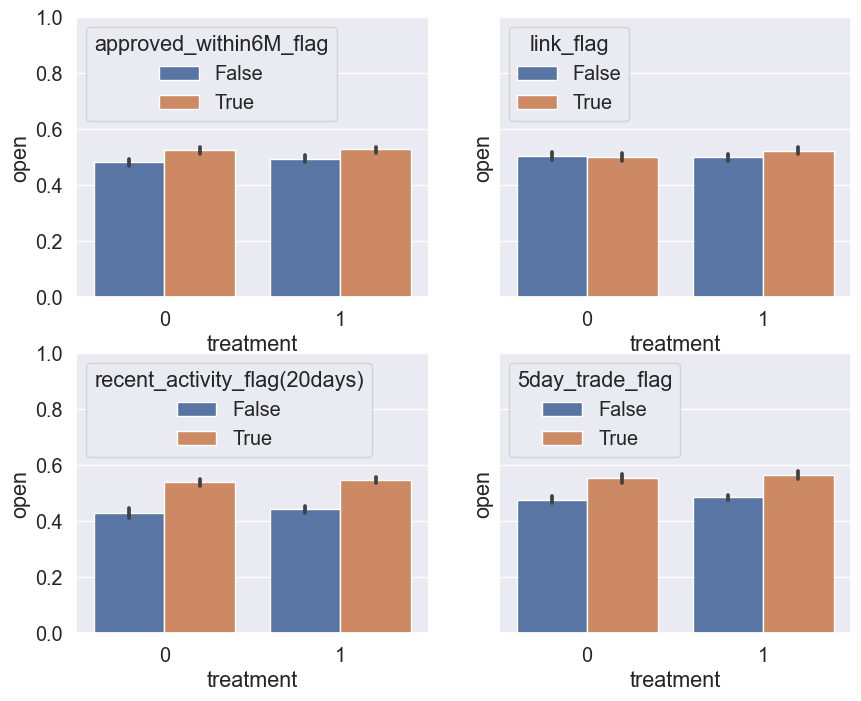

```python
fig, ((ax1, ax2), (ax3, ax4)) = plt.subplots(nrows=2, ncols=2, figsize=(10, 8), sharey=True)

sns.barplot(data, y="open", x="treatment", hue="approved_within6M_flag", ax=ax1)
sns.barplot(data, y="open", x="treatment", hue="link_flag", ax=ax2)
sns.barplot(data, y="open", x="treatment", hue="recent_activity_flag(20days)", ax=ax3)
sns.barplot(data, y="open", x="treatment", hue="5day_trade_flag", ax=ax4)

ax1.legend(loc="upper left", title="approved_within6M_flag")
ax2.legend(loc="upper left", title="link_flag")
ax3.legend(loc="upper left", title="recent_activity_flag(20days)")
ax4.legend(loc="upper left", title="5day_trade_flag")

ax1.set_ylim([0, 1])

plt.show()
```

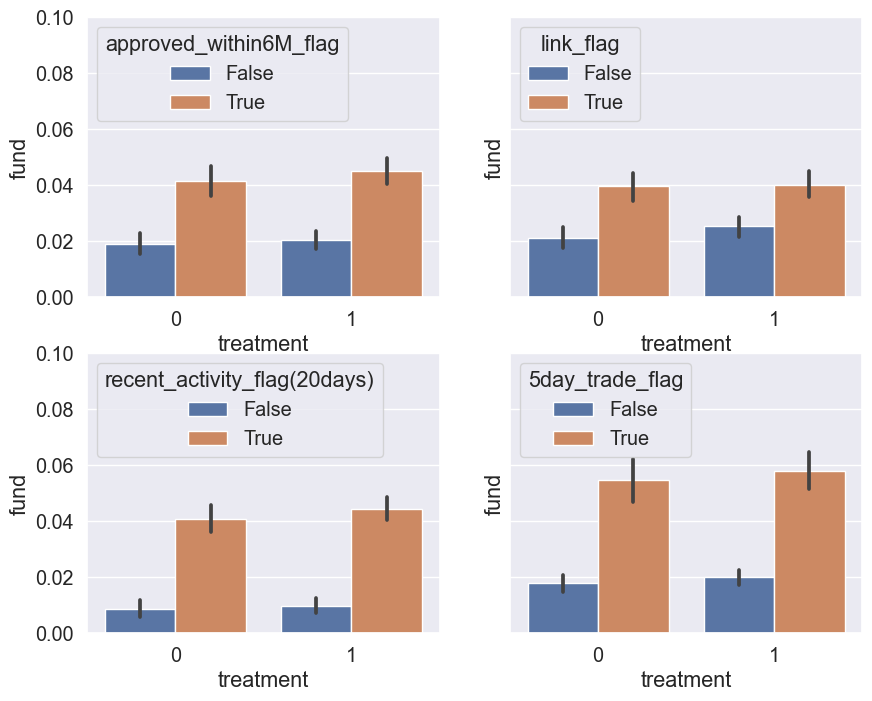

```python
fig, ((ax1, ax2), (ax3, ax4)) = plt.subplots(nrows=2, ncols=2, figsize=(10, 8), sharey=True)

sns.barplot(data, y="fund", x="treatment", hue="approved_within6M_flag", ax=ax1)
sns.barplot(data, y="fund", x="treatment", hue="link_flag", ax=ax2)
sns.barplot(data, y="fund", x="treatment", hue="recent_activity_flag(20days)", ax=ax3)
sns.barplot(data, y="fund", x="treatment", hue="5day_trade_flag", ax=ax4)

ax1.legend(loc="upper left", title="approved_within6M_flag")
ax2.legend(loc="upper left", title="link_flag")
ax3.legend(loc="upper left", title="recent_activity_flag(20days)")
ax4.legend(loc="upper left", title="5day_trade_flag")

ax1.set_ylim([0, 0.1])

plt.show()
```

```python
psm = PsmPy(data, treatment="treatment", indx="user_uuid", exclude = ["open", "fund"])
```

```python
psm.logistic_ps(balance = True)
```

```python
psm.predicted_data
```

|  | user_uuid | approved_within6M_flag | link_flag | recent_activity_flag(20days) | 5day_trade_flag | propensity_score | propensity_logit | treatment |
| --- | --- | --- | --- | --- | --- | --- | --- | --- |
| 0 | id_5986357721607423793 | True | False | True | True | 0.495571 | -0.017718 | 0 |
| 1 | id_1270658246928165193 | True | False | False | False | 0.494895 | -0.020420 | 0 |
| 2 | id_14400729331367639383 | False | False | True | True | 0.497356 | -0.010574 | 0 |
| 3 | id_10426350145121012443 | False | False | True | False | 0.505453 | 0.021811 | 0 |
| 4 | id_17589544048255138557 | False | False | False | False | 0.496679 | -0.013283 | 0 |
| ... | ... | ... | ... | ... | ... | ... | ... | ... |
| 24995 | id_8205952884211702117 | True | False | False | False | 0.483331 | -0.066702 | 1 |
| 24996 | id_18141166836216367851 | True | False | True | False | 0.510505 | 0.042027 | 1 |
| 24997 | id_18220517370148956642 | False | False | False | False | 0.487387 | -0.050464 | 1 |
| 24998 | id_4836987591347191585 | False | False | True | False | 0.514562 | 0.058266 | 1 |
| 24999 | id_18176957599244800006 | False | False | True | False | 0.514562 | 0.058266 | 1 |

25000 rows × 8 columns

```python
psm.predicted_data = pd.merge(psm.predicted_data, data[["user_uuid","open", "fund"]], on="user_uuid", how="inner")
```

```python
psm.predicted_data.describe()
```

|  | propensity_score | propensity_logit | treatment | open | fund |
| --- | --- | --- | --- | --- | --- |
| count | 25000.000000 | 25000.000000 | 25000.000000 | 25000.000000 | 25000.000000 |
| mean | 0.500019 | 0.000077 | 0.600000 | 0.508080 | 0.031720 |
| std | 0.006536 | 0.026150 | 0.489908 | 0.499945 | 0.175257 |
| min | 0.483331 | -0.066702 | 0.000000 | 0.000000 | 0.000000 |
| 25% | 0.496612 | -0.013553 | 0.000000 | 0.000000 | 0.000000 |
| 50% | 0.497285 | -0.010860 | 1.000000 | 1.000000 | 0.000000 |
| 75% | 0.505972 | 0.023889 | 1.000000 | 1.000000 | 0.000000 |
| max | 0.518588 | 0.074384 | 1.000000 | 1.000000 | 1.000000 |

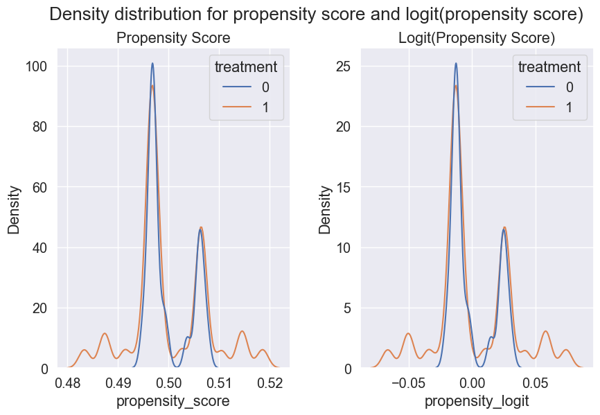

```python
# Density distribution of propensity score (logic) broken down by treatment status
fig, ax = plt.subplots(1,2, figsize = (10, 6))
fig.suptitle('Density distribution for propensity score and logit(propensity score)')
sns.kdeplot(x = psm.predicted_data["propensity_score"], hue = psm.predicted_data["treatment"], ax = ax[0])
ax[0].set_title('Propensity Score')
sns.kdeplot(x = psm.predicted_data["propensity_logit"], hue = psm.predicted_data["treatment"], ax = ax[1])
ax[1].set_title('Logit(Propensity Score)')
plt.subplots_adjust(wspace = 0.3)
plt.show()
```

```python
# 1:1 matching
caliper = np.std(psm.predicted_data.propensity_score) * 0.25
print(caliper)
psm.knn_matched(matcher='propensity_logit', replacement=False, caliper=caliper, drop_unmatched=True)
```

```
0.0016340243225641139
```

```python
psm.df_matched
```

|  | user_uuid | approved_within6M_flag | link_flag | recent_activity_flag(20days) | 5day_trade_flag | propensity_score | propensity_logit | treatment | open | fund | matched_ID |
| --- | --- | --- | --- | --- | --- | --- | --- | --- | --- | --- | --- |
| 0 | id_1270658246928165193 | True | False | False | False | 0.494895 | -0.020420 | 0 | 1 | 0 | id_16012895567059881386 |
| 1 | id_14400729331367639383 | False | False | True | True | 0.497356 | -0.010574 | 0 | 1 | 0 | id_5713841004801129666 |
| 2 | id_17589544048255138557 | False | False | False | False | 0.496679 | -0.013283 | 0 | 0 | 0 | id_2180434812229046698 |
| 3 | id_13362130885304740224 | True | False | False | False | 0.494895 | -0.020420 | 0 | 1 | 0 | id_15529484824852526734 |
| 4 | id_3523047412030291854 | False | True | False | False | 0.498920 | -0.004318 | 0 | 0 | 0 | id_15383831735990854897 |
| ... | ... | ... | ... | ... | ... | ... | ... | ... | ... | ... | ... |
| 15024 | id_18141847805866728021 | False | True | True | True | 0.496612 | -0.013553 | 1 | 1 | 0 | NaN |
| 15025 | id_408332919652790354 | False | False | True | False | 0.496343 | -0.014629 | 1 | 0 | 0 | NaN |
| 15026 | id_13985913042458800254 | False | False | False | False | 0.505972 | 0.023889 | 1 | 0 | 0 | NaN |
| 15027 | id_10299400496330353277 | True | False | False | False | 0.506460 | 0.025840 | 1 | 0 | 0 | NaN |
| 15028 | id_4548243747063805527 | False | False | False | False | 0.505972 | 0.023889 | 1 | 0 | 0 | NaN |

15029 rows × 11 columns

```python
psm.df_matched.shape
```

```
(15029, 11)
```

```python
psm.df_matched["matched_ID"].isna().sum()
```

```
7514
```

```python
psm.df_matched["matched_ID"].notna().sum()
```

```
7515
```

```python
psm.df_matched["treatment"].value_counts()
```

```
treatment
0    7515
1    7514
Name: count, dtype: int64
```

```python
treated = psm.df_matched[psm.df_matched["treatment"]==1]
control = psm.df_matched[psm.df_matched["treatment"]==0]
treated.loc[:, "matched_ID"] = treated["user_uuid"]
test = pd.concat([control, treated], axis=0)
```

```python
test.duplicated("matched_ID", keep=False).value_counts()
```

```
True     15028
False        1
Name: count, dtype: int64
```

```python
df_matched = test[test.duplicated("matched_ID", keep=False)]
```

```python
df_matched.shape
```

```
(15028, 11)
```

```python
psm_df = df_matched.copy()
psm_df.describe()
```

|  | propensity_score | propensity_logit | treatment | open | fund |
| --- | --- | --- | --- | --- | --- |
| count | 15028.000000 | 15028.000000 | 15028.000000 | 15028.000000 | 15028.000000 |
| mean | 0.499327 | -0.002693 | 0.500000 | 0.502861 | 0.031475 |
| std | 0.004278 | 0.017112 | 0.500017 | 0.500008 | 0.174602 |
| min | 0.494496 | -0.022016 | 0.000000 | 0.000000 | 0.000000 |
| 25% | 0.496645 | -0.013420 | 0.000000 | 0.000000 | 0.000000 |
| 50% | 0.497100 | -0.011602 | 0.500000 | 1.000000 | 0.000000 |
| 75% | 0.505909 | 0.023636 | 1.000000 | 1.000000 | 0.000000 |
| max | 0.506914 | 0.027658 | 1.000000 | 1.000000 | 1.000000 |

### Matching Review

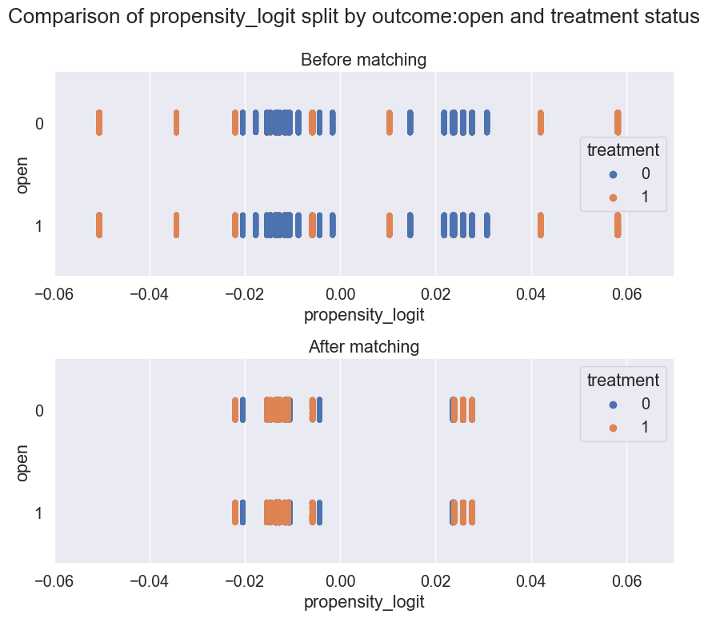

```python
fig, ax = plt.subplots(2,1, figsize=(10, 8))
fig.suptitle('Comparison of {} split by outcome:open and treatment status'.format('propensity_logit'))
sns.stripplot(data = psm.predicted_data, y = 'open', x = 'propensity_logit', hue = 'treatment',
              orient = 'h', ax = ax[0]).set(title = 'Before matching', xlim=(-0.06, 0.07))
sns.stripplot(data = psm_df, y = 'open', x = 'propensity_logit', hue = 'treatment',
              orient = 'h', ax = ax[1]).set(title = 'After matching', xlim=(-0.06, 0.07))
plt.subplots_adjust(hspace = 0.4)
plt.show()
```

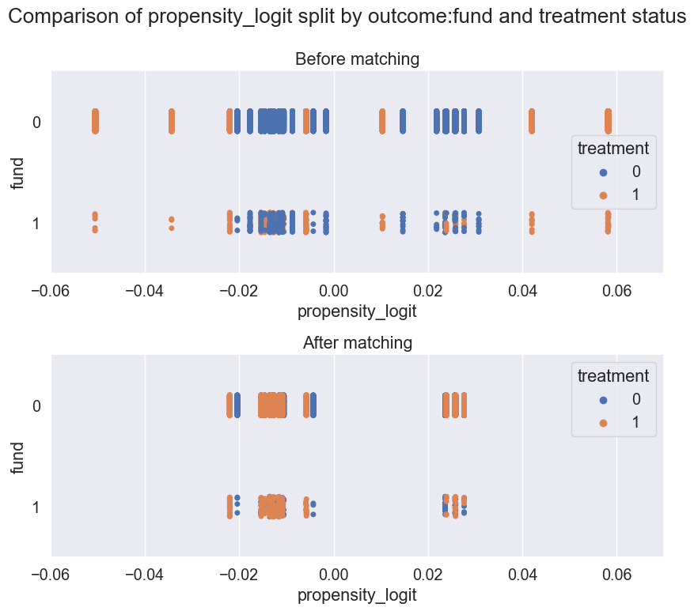

```python
fig, ax = plt.subplots(2,1, figsize=(10, 8))
fig.suptitle('Comparison of {} split by outcome:fund and treatment status'.format('propensity_logit'))
sns.stripplot(data = psm.predicted_data, y = 'fund', x = 'propensity_logit', hue = 'treatment',
              orient = 'h', ax = ax[0]).set(title = 'Before matching', xlim=(-0.06, 0.07))
sns.stripplot(data = psm_df, y = 'fund', x = 'propensity_logit', hue = 'treatment',
              orient = 'h', ax = ax[1]).set(title = 'After matching', xlim=(-0.06, 0.07))
plt.subplots_adjust(hspace = 0.4)
plt.show()
```

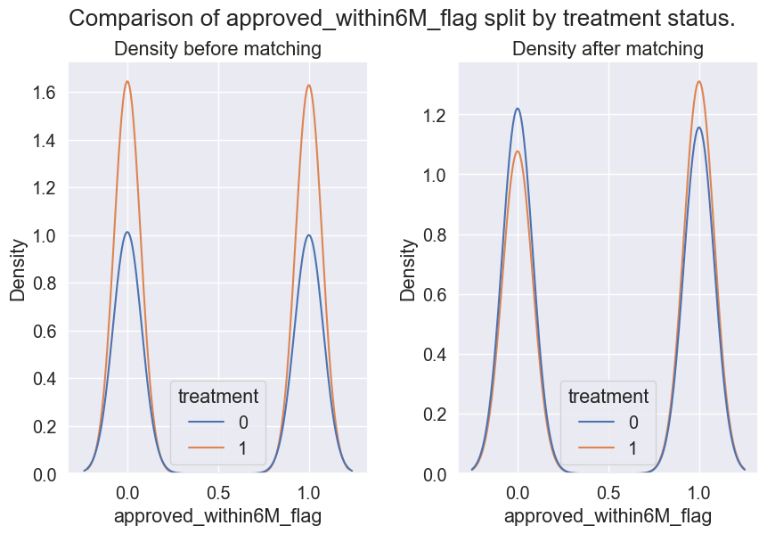

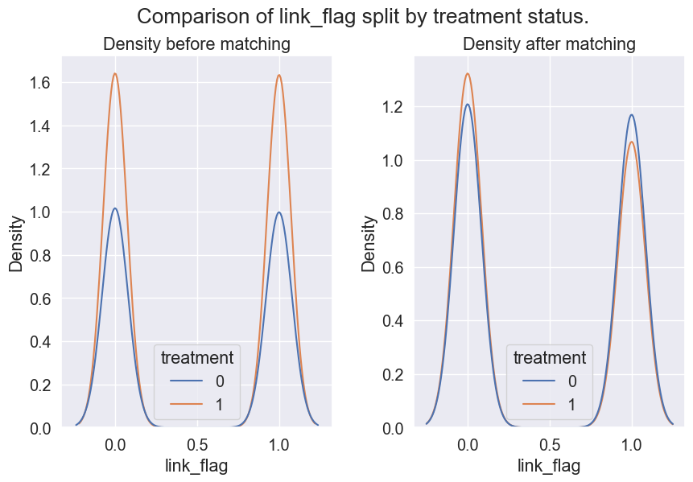

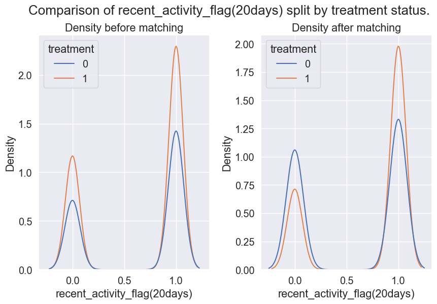

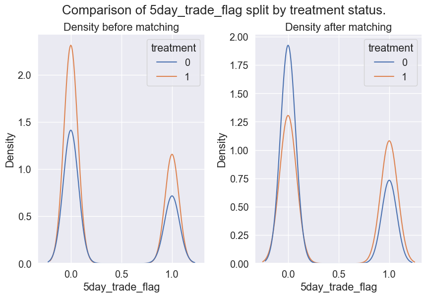

```python
args = ["approved_within6M_flag", "link_flag",
        "recent_activity_flag(20days)", "5day_trade_flag"]

def plot(arg):
    fig, ax = plt.subplots(1,2, figsize=(10, 6), sharex=True)
    fig.suptitle('Comparison of {} split by treatment status.'.format(arg))
    sns.kdeplot(data = psm.predicted_data, x = arg, hue = 'treatment', ax = ax[0]).set(title='Density before matching')
    sns.kdeplot(data = psm_df, x = arg, hue = 'treatment',  ax = ax[1]).set(title='Density after matching')
    plt.subplots_adjust(wspace = 0.3)
    plt.show()

for arg in args:
    plot(arg)
```

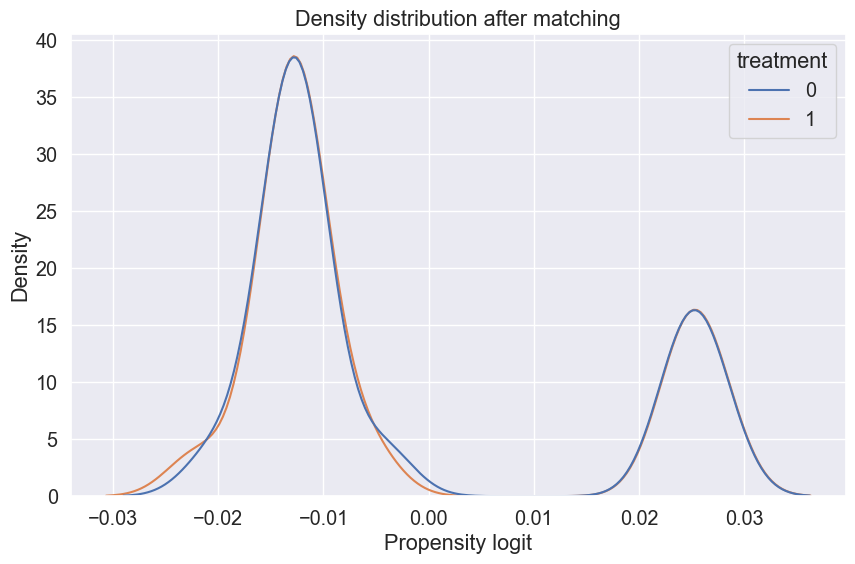

```python
plt.figure(figsize = (10, 6))
sns.kdeplot(x = psm_df["propensity_logit"], hue = psm_df["treatment"])
plt.title('Density distribution after matching')
plt.xlabel("Propensity logit")
plt.show()
```

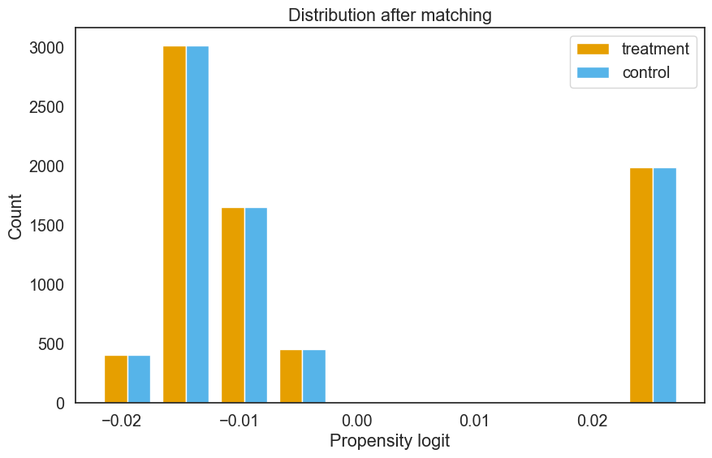

```python
plt.figure(figsize = (10, 6))
psm.plot_match(Title='Distribution after matching',
               Ylabel='Count', Xlabel= 'Propensity logit',
               names = ['treatment', 'control'], save=False)
```

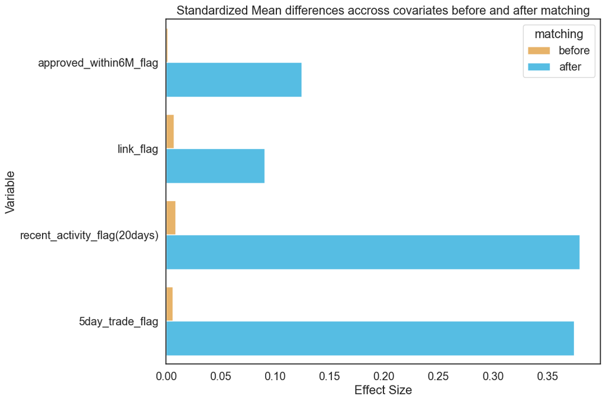

```python
psm.effect_size_plot(save=False)
```

### Average Treatment Effect

```python
overview = psm_df[['open', 'fund','treatment']].groupby(by = ['treatment']).agg(["mean", "var", 'count'])
overview
```

| treatment | open mean | open var | open count | fund mean | fund var | fund count |
| --- | --- | --- | --- | --- | --- | --- |
| 0 | 0.486958 | 0.249863 | 7514 | 0.023556 | 0.023004 | 7514 |
| 1 | 0.518765 | 0.249681 | 7514 | 0.039393 | 0.037846 | 7514 |

```python
treated_open = overview['open']['mean'][1]
treated_counterfactual_open = overview['open']['mean'][0]
treated_fund = overview['fund']['mean'][1]
treated_counterfactual_fund = overview['fund']['mean'][0]
```

```python
att_open = treated_open - treated_counterfactual_open
print('The Average Treatment Effect (ATT) for the openning rate: {:.4f}'.format(att_open))
att_fund = treated_fund - treated_counterfactual_fund
print('The Average Treatment Effect (ATT) for the funding rate: {:.4f}'.format(att_fund))
```

```
The Average Treatment Effect (ATT) for the openning rate: 0.0318
The Average Treatment Effect (ATT) for the funding rate: 0.0158
```

- OPENING

$H_0: P_D < P_W$  
(daily delivery has a lower opening rate than twice-a-week delivery)

$H_a: P_D > P_W$  
(daily delivery has a higher opening rate than twice-a-week delivery)

$p-value=0.000<0.05$, so we reject the null hypothesis and conclude that **daily delivery has a higher opening rate than twice-a-week delivery**.

```python
t, p = stats.ttest_ind(
    psm_df[psm_df['treatment']==1]['open'],
    psm_df[psm_df['treatment']==0]['open'],
    equal_var=False,
    alternative='greater' #‘greater’: the mean of the distribution underlying the first sample is greater than the mean of the distribution underlying the second sample
)
print("The t-value is %0.3f and the p-value is %0.4f." % (t, p))
```

```
The t-value is 3.901 and the p-value is 0.0000.
```

- FUNDING

$H_0: P_D < P_W$  
(daily delivery has a lower funding rate than twice-a-week delivery)

$H_a: P_D > P_W$  
(daily delivery has a higher funding rate than twice-a-week delivery)

$p-value=0.0000<0.05$, so we reject the null hypothesis and conclude that **daily delivery has a higher funding rate than twice-a-week delivery**.

```python
t, p = stats.ttest_ind(
    psm_df[psm_df['treatment']==1]['fund'],
    psm_df[psm_df['treatment']==0]['fund'],
    equal_var=False,
    alternative='greater' #‘greater’: the mean of the distribution underlying the first sample is greater than the mean of the distribution underlying the second sample
)
print("The t-value is %0.3f and the p-value is %0.4f." % (t, p))
```

```
The t-value is 5.565 and the p-value is 0.0000.
```